# Trading Strategy

The purpose of this notebook is to use statistic and plotting packages on the explosive_data_clean.csv file to uncover patterns that might help establish a profitable trading strategy. For a definition of column attributes please reference the attached READ ME in the Git Hub repository.

I begin by importing tha packages I will use. Then I import the dataset and assign it to the variable ‘data’

```r
library(tidyverse)
library(lmtest)
data = read.csv('explosive_data_clean.csv', header = TRUE)
head(data)
```

|  | row | ticker | flag | daily_increase | news | highs | move | rsi | short_percent | volume | industry | three_day_return | one_week_return | two_week_return | absolute_high | second_day | announcments |
| --- | --- | --- | --- | --- | --- | --- | --- | --- | --- | --- | --- | --- | --- | --- | --- | --- | --- |
| 1 | 20 | ALLK | Y | 17.5 | no | 14 | cont | 58 | 1.3 | NULL | health tech | -75.6 | NULL | NULL | 0 | DR | yes |
| 2 | 149 | BSLK | G | 290.7 | no | 12 mo | initial | 87 | 2.4 | 15000 | finance | -43.5 | NULL | NULL | NULL | NULL | NULL |
| 3 | 98 | SGBX | G | 75.2 | recent buisness | 21 | second | 70 | 0.6 | 31000 | manufacturing | -45.3 | NULL | NULL | 0 | DR | n |
| 4 | 25 | COCH | R | 3.9 | no | 14 | initial | 48 | 1.65 | 30 | health tech | -5.3 | NULL | NULL | 0 | DR | NULL |
| 5 | 85 | SB | B | 5.8 | recent buisness | 21 | initial | 56 | 2.6 | 1300 | transportation | -1.9 | -0.77 | 0.6 | 2.2 | UG | yes |
| 6 | 66 | OCTO | R | 8.4 | no | 7 | second | 49 | 4.8 | 5000 | Tech | -12.7 | NULL | NULL | 0 | DG | n |

Notice that all columns have been cast as character even though they are intended to be numeric. For data I wish to run functions on I will need to convert to numeric data types.

```r
data$three_day_return <- as.numeric(as.character(data$three_day_return))
data$daily_increase <- as.numeric(as.double(data$daily_increase))
data$short_percent <- as.numeric(as.double(data$short_percent))
```

I want to start by looking at three_day_return based on rsi and flag color.

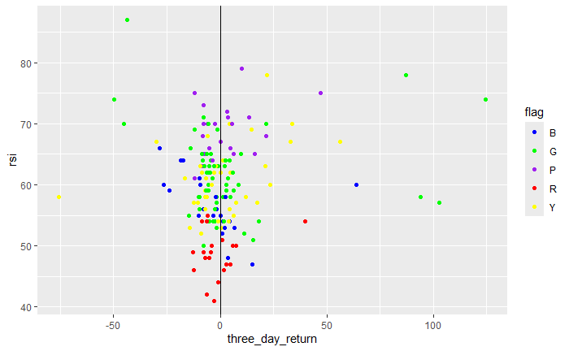

```r
ggplot(
   data = data,
  mapping = aes(x = three_day_return, y = rsi)
) + geom_point(mapping = aes(color = flag)
) +  scale_color_manual(values = c("B" = "blue", "G" = "green",
                                     'P' = "purple", "R" = 'red',
                                     'Y' = 'yellow')
) + geom_vline(xintercept = 0, linetype = 'solid', color = 'black')
```

Things that stand out from this plot..

1. Red flag trades are all less than 55 RSI and there are significantly more losers than winners.
2. There were the same number of purple winners and losers and the winner on average won more than the losers.
3. Blue flags appear to have a moderate negative correlation with profits where a higher RSI yields lagrer losses.
4. There appears to be the presence of heteroscedasticity in the data, where as RSI increases the variance of profit and loss becomes greater.

Now I will run some basic commands to quantify and verify my visual observations.

```r
R_flag_data <- filter(data, flag == 'R')
R_flag_winners <- filter(R_flag_data, three_day_return > 0.0)
R_flag_losers <- filter(R_flag_data, three_day_return < 0.0)

P_flag_data <- filter(data, flag == 'P')
P_flag_winners <- filter(P_flag_data, three_day_return > 0.0)
P_flag_losers <- filter(P_flag_data, three_day_return < 0.0)
P_avg_winner <- round(mean(P_flag_winners$three_day_return))
P_avg_loser <- round(mean(P_flag_losers$three_day_return))

B_flag_data <- filter(data, flag == 'B')
cor(B_flag_data$rsi, B_flag_data$three_day_return, use = "complete.obs")
```

```
[1] -0.3804022
```

```r
model <- lm(rsi ~ three_day_return, data = data)
breusch_pagan_test <-bptest(model)
breusch_pagan_test
```

```
    studentized Breusch-Pagan test

data:  model
BP = 0.13217, df = 1, p-value = 0.7162
```

The results from this analysis shows that..

1. There are in fact 7 Winners and 13 losers under the red flags
2. There were 11 and 11 respectivly with the winner returning a mean profit of 12% and losers returning a mean loss of 7%.
3. There is in fact a -.38 correlation between RSI and three_day_returns for blue flags.
4. The Breusch-Pagan test return a BP statistic of .13 and a P-value of .71 which is not significant. There is not strong evidence of the presence of heteroscedasticity in the data.

Next I want to see how daily_increase impacts three_day_return.

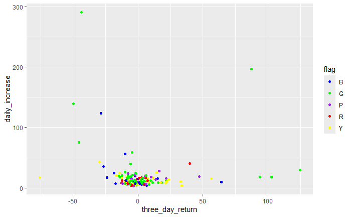

```r
ggplot(
   data = data,
  mapping = aes(x = three_day_return, y = daily_increase)
) + geom_point(mapping = aes(color = flag)
) +  scale_color_manual(values = c("B" = "blue", "G" = "green",
                                     'P' = "purple", "R" = 'red',
                                     'Y' = 'yellow')
)
```

Just by looking at this graph it appears that avoiding trades with a daily_increase greater than 50 eliminates 6 losers while keeping nearly all of my largest winners.

Finally, I want to look at how short_percent impacts three_day_return.

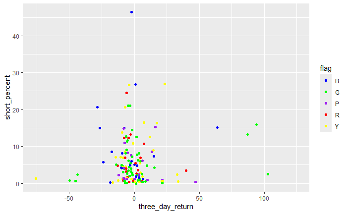

```r
ggplot(
   data = data,
  mapping = aes(x = three_day_return, y = short_percent)
) + geom_point(mapping = aes(color = flag)
) +  scale_color_manual(values = c("B" = "blue", "G" = "green",
                                     'P' = "purple", "R" = 'red',
                                     'Y' = 'yellow')
)
```

Based off the information I have gathered from this analysis I want to begin formulating my strategy.

–I will only take trades that are above 55 RSI.

–I will only take trades with a short % less than 20.

–I will only take trades that have a daily increase of less than 50%.

–I will only hold trades for three days and sell at the close of the third day.

Applying these limitations to the data my theoretical strategy will yield…

37 Winners and 51 Losers with a win percent of 42%

Average profit of 17.2%

Average loss of 9%

Total Profit 636.9%

Total Loss 458.9%

A Net Profit of 178%

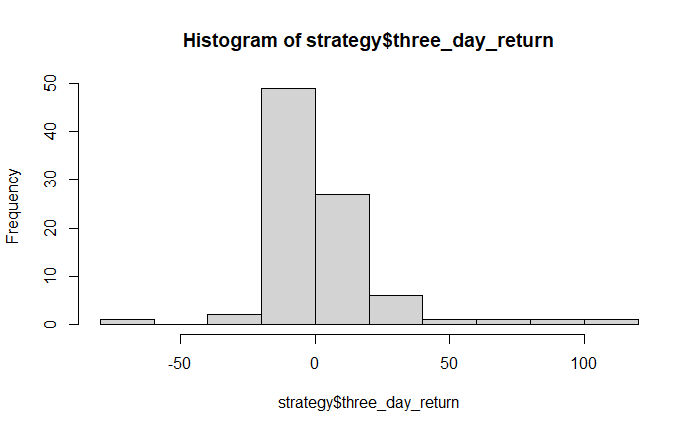

```r
rsi_filter <- filter(data, rsi > 55)
short_per_filter <- filter(rsi_filter, short_percent < 20)
strategy <- filter(short_per_filter, daily_increase < 50)

num_winner <- sum(strategy$three_day_return > 0)
win_avg_per <- mean(strategy$three_day_return[strategy$three_day_return > 0])
total_profit <- sum(strategy$three_day_return[strategy$three_day_return > 0])

num_loser <- sum(strategy$three_day_return < 0)
loss_avg_per <- mean(strategy$three_day_return[strategy$three_day_return < 0])
total_loss <- sum(strategy$three_day_return[strategy$three_day_return < 0])

hist(strategy$three_day_return,breaks = 10)
```